# Los Angeles City Council: local ideal points, 2004–2026

A preliminary pooled voting history across eleven council compositions

Author

Boris Shor

Updated

October 9, 2026

Los Angeles’s council voting history covers 2004–2026. The expanded analysis places 45 members on one voting spectrum, connecting earlier councils to today’s through their overlapping membership. It shows both the range of positions within a largely Democratic council and the emergence of a distinct socialist-endorsed group. Council-by-council views show how the membership changed across elections.

**45 members**  
Pooled across 2004–2026

**11 council windows**  
Membership across elections

**1,468 roll calls**  
Contested council decisions

**18,062 votes**  
Recorded yeas and nays

## Dataset and construction

The analysis combines published recent roll-call votes with votes recovered directly from the City Clerk’s [historical council journals](https://ens2.lacity.org/enssubscribe2/netdocs/index.cfm?CSS=77113&FD=2&FS=1&SI=&SP=&catid=6&rootcat=6). The earlier journals identify dissenters and absentees; the remaining members are counted as yeas only when that reconstruction agrees with the printed tally. Repeated references to the same numbered roll call are treated as one vote, even when it disposed of several agenda items.

| Measure | Value |
| --- | --- |
| Members fitted | 45 |
| Qualifying roll calls | 1,468 |
| Recorded yea/nay votes | 18,062 |
| Recovered historical roll calls | 844 |
| Recent published roll calls | 624 |
| First qualifying vote | 2004-01-20 |
| Last qualifying vote | 2026-09-08 |

A vote qualifies when at least one member votes on each side and at least ten members cast yea or nay. Members need at least seven qualifying votes. This keeps lone-dissenter votes, which are informative in a fifteen-member council, while excluding near-empty records. Absence is not opposition, and a missing record is not a recorded vote.

Historical coverage is substantial but not exhaustive: journals with unreadable rosters or unreconciled tallies are excluded rather than filled in. **Tim McOsker remains missing from the recent vote export**, so the latest council view has fourteen members. The technical appendix documents construction, coverage checks and estimation. The earlier 2021–2026 report remains available separately.

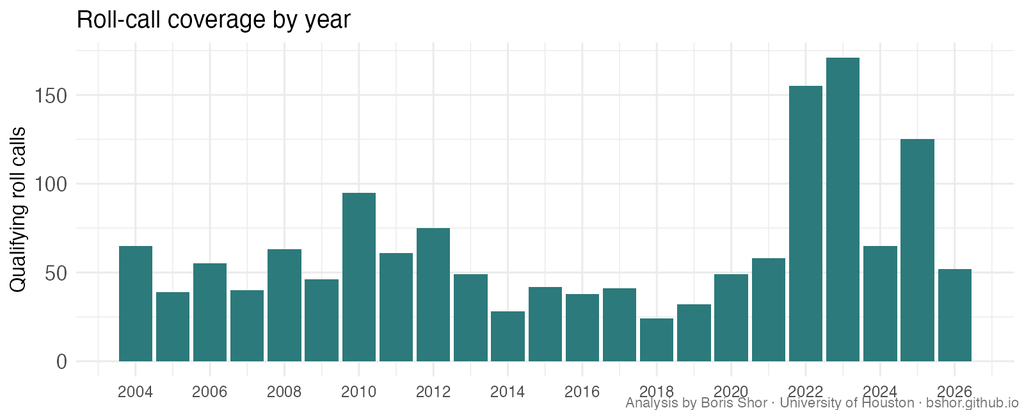

## The pooled council spectrum

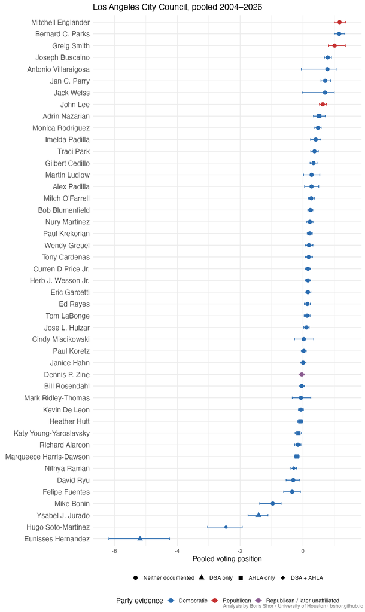

Colors distinguish researched party affiliations. Symbols distinguish documented DSA and Abundant Housing LA endorsements, kept as separate indicators. An unmarked member has no endorsement documented here—not necessarily no endorsement historically. Each member has one pooled estimate; the intervals show uncertainty around that estimate.

| End of spectrum | Voting position | Qualifying votes |
| --- | --- | --- |
| Eunisses Hernandez | -5.18 | 405 |
| Mitchell Englander | 1.16 | 292 |

## Presidential voting by council district

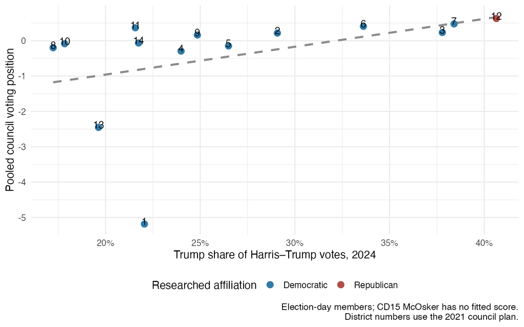

Members from more Republican-voting districts generally sit further right on the council spectrum, although the relationship is far from uniform (Pearson correlation 0.40). John Lee’s district has the highest Trump share; Hernandez and Soto-Martínez sit well to the left of colleagues from similarly Democratic districts. Party alone does not capture these differences within the council.

The comparison uses the members serving on Election Day, November 5, 2024—including Krekorian and de León, not their December successors. Fourteen districts have fitted members; McOsker’s is missing. Presidential returns are aggregated from [published 2024 precinct results](https://github.com/nytimes/presidential-precinct-map-2024) using the 2021 council map. Boundary-crossing precincts require approximate allocation; the appendix describes the checks and assumptions.

## Policy context

The recent council’s disagreements cover policing, homelessness and labor policy. Hernandez, Raman and Soto-Martínez opposed the 2023 police-pay agreement over budget priorities; it passed 12–3. [CBS/City News Service](https://www.cbsnews.com/losangeles/news/la-city-council-approves-contract-increasing-pay-of-lapd-officers/)

Buscaino advocated tougher encampment restrictions, while Bonin and Raman opposed the 2021 anti-camping ordinance. [Los Angeles Times](https://www.latimes.com/california/story/2021-07-28/anti-camping-vote-la-homelessness)

Three reported votes illustrate Monica Rodriguez’s emphasis on public safety and her opposition to some recent council initiatives:

- **Police hiring and the budget, May 22, 2025:** Rodriguez, Lee and Park opposed the revised budget, which advanced 12–3. They objected to inadequate public-safety funding and a reduction in planned LAPD recruitment from 480 to 240 officers. [City News Service/Spectrum](https://spectrumlocalnews.com/ca/california/politics/2025/05/22/mayor-karen-bass--budget)
- **Tourism-worker wages, May 14, 2025:** the same three opposed the preliminary plan for a $30 minimum wage by 2028 for hotel and airport workers. Rodriguez and Park also sought different treatment for contracted, variable-hour workers. [City News Service](https://mynewsla.com/business/2025/05/14/la-council-preliminary-approves-wage-increase-for-hotel-and-airport-workers/)
- **Encampment restrictions, August 2026:** Rodriguez, Park and Padilla opposed repealing twelve camping bans; the repeal passed 10–3. [Los Angeles Times](https://www.latimes.com/california/story/2026-08-19/la-city-council-repeals-homeless-camping-bans-in-echo-park-silver-lake-hollywood)

These examples supply policy context, not a claim that every disagreement is about the same issue.

## Councils across elections

The tabs share a common horizontal axis and the same pooled estimates. Windows follow the turnover of staggered elected council seats, including replacements within a council. The 2015 and 2017 terms were extended as LA shifted to even-year elections, so there is no invented 2019 turnover. [City Charter, section 205](https://codelibrary.amlegal.com/codes/los_angeles/latest/laac/0-0-0-425)

**2004–2005**

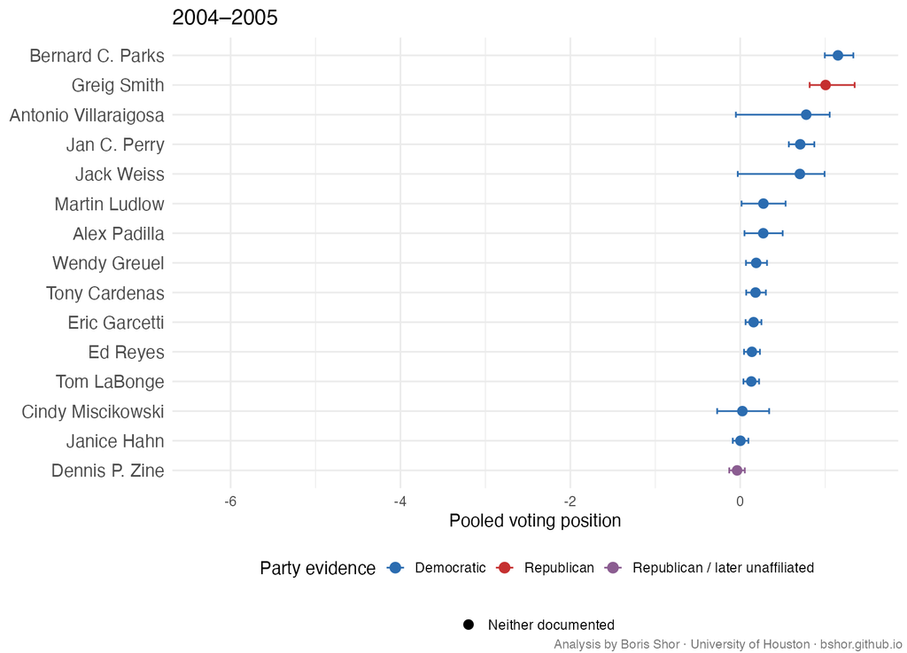

Los Angeles council voting positions for 2004–2005.

**2005–2007**

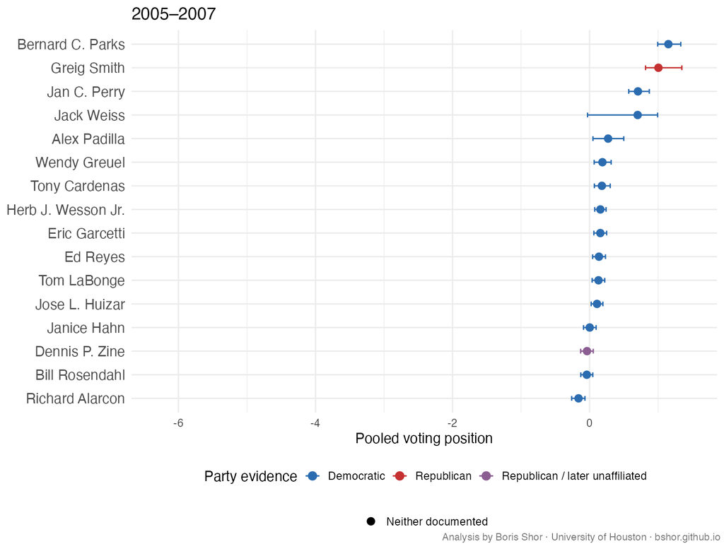

Los Angeles council voting positions for 2005–2007.

**2007–2009**

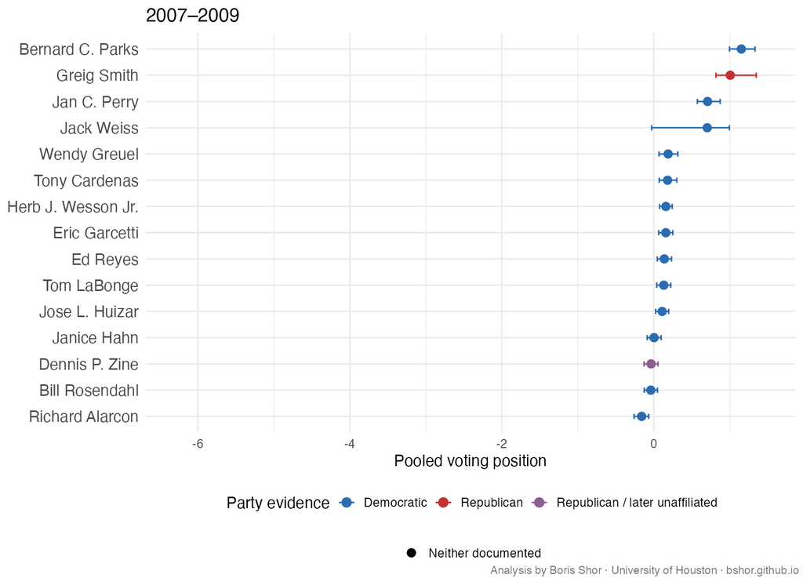

Los Angeles council voting positions for 2007–2009.

**2009–2011**

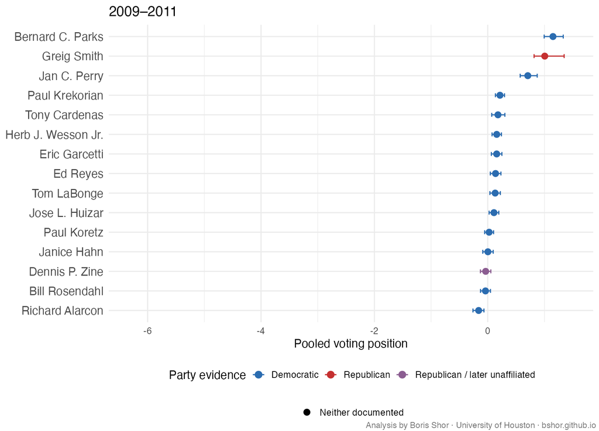

Los Angeles council voting positions for 2009–2011.

**2011–2013**

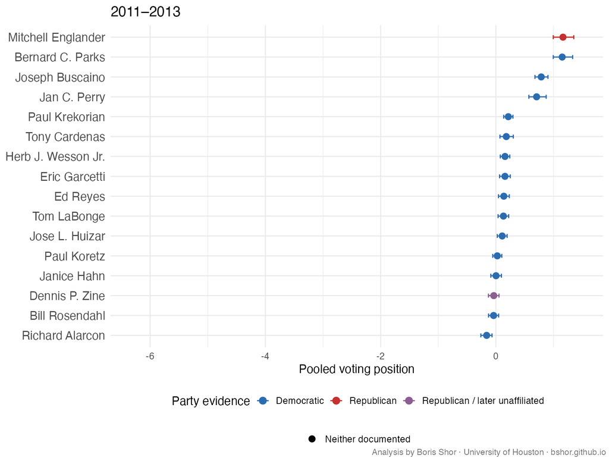

Los Angeles council voting positions for 2011–2013.

**2013–2015**

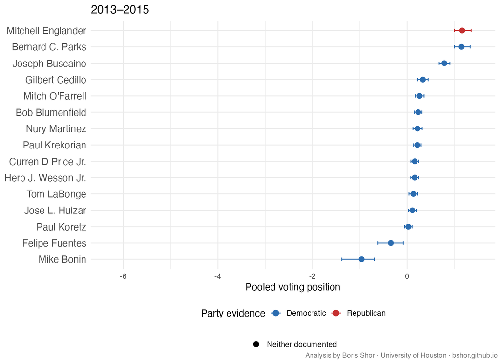

Los Angeles council voting positions for 2013–2015.

**2015–2017**

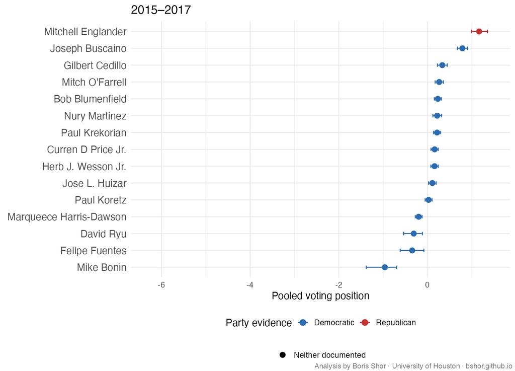

Los Angeles council voting positions for 2015–2017.

**2017–2020**

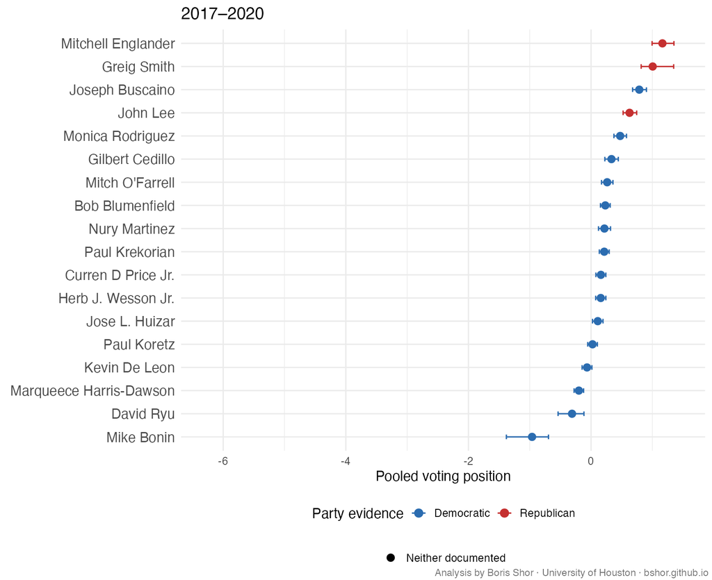

Los Angeles council voting positions for 2017–2020.

**2020–2022**

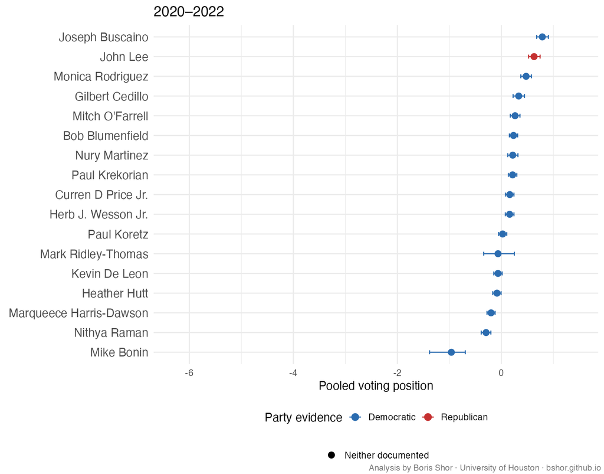

Los Angeles council voting positions for 2020–2022.

**2022–2024**

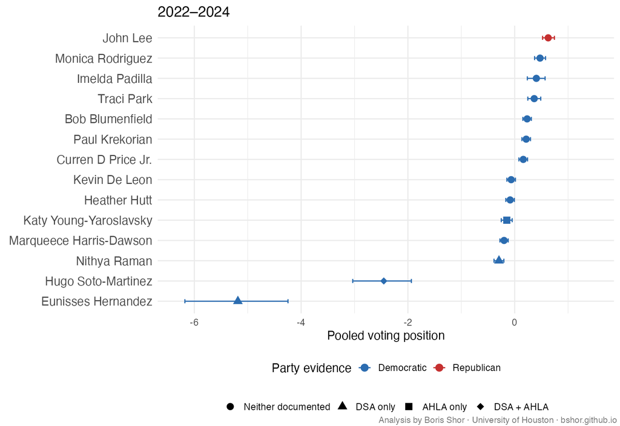

Los Angeles council voting positions for 2022–2024.

**2024–2026**

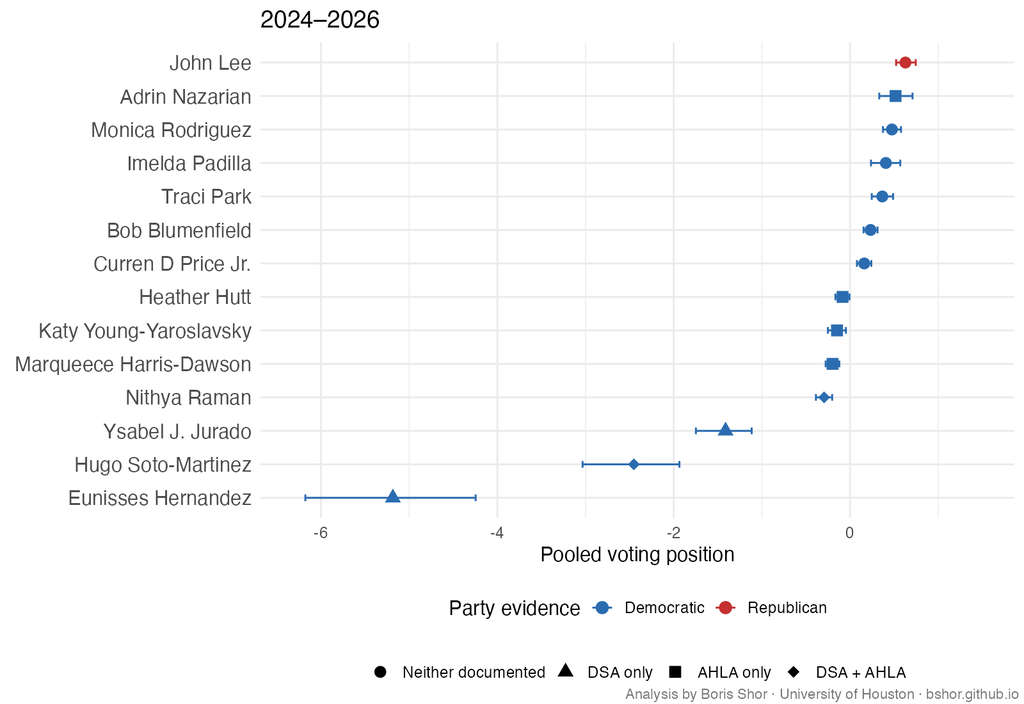

Los Angeles council voting positions for 2024–2026.

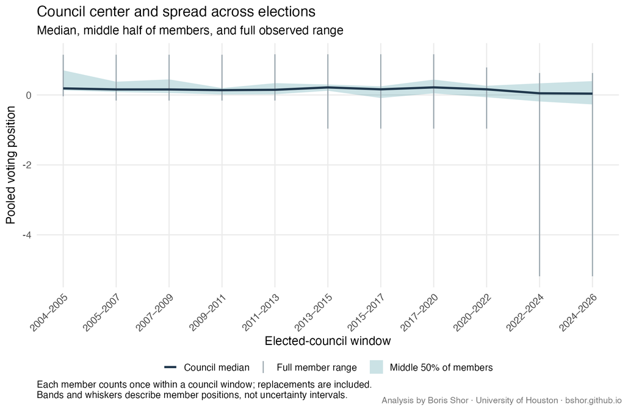

Council medians over time, with a shaded band for the middle 50% of members and thin whiskers for the full range. These show dispersion across members, not uncertainty in an estimate.

The first window starts partway through the council elected in 2003. These are changes in council composition, not estimates of individual members moving over time. Historical organizational endorsement coverage is incomplete; later endorsements are not projected backward onto earlier councils.

## Voting distributions and polarization

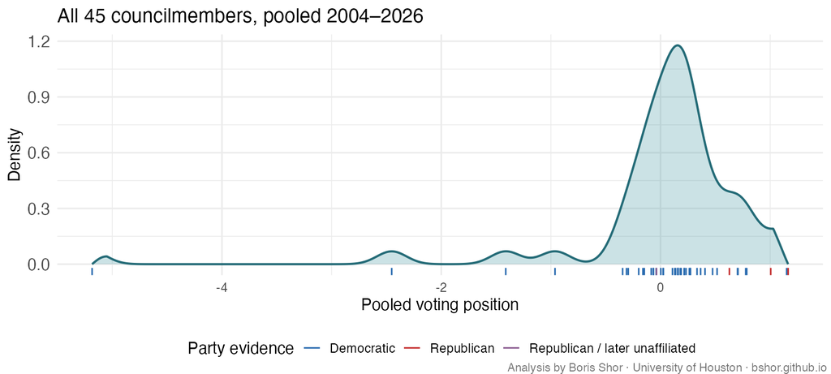

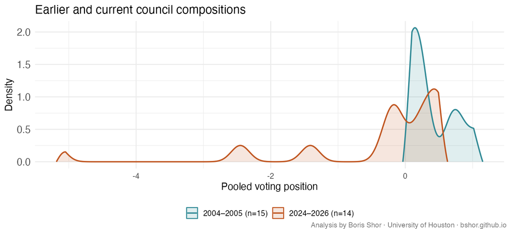

The curves summarize members’ estimated positions, not the number of votes they cast. The earlier/current overlay uses the same smoothing for both groups. Curves taper to zero at the outermost members rather than extending beyond them. Each distribution counts a member once, including replacements who served during that window. The median-and-spread chart above summarizes changes across council windows.

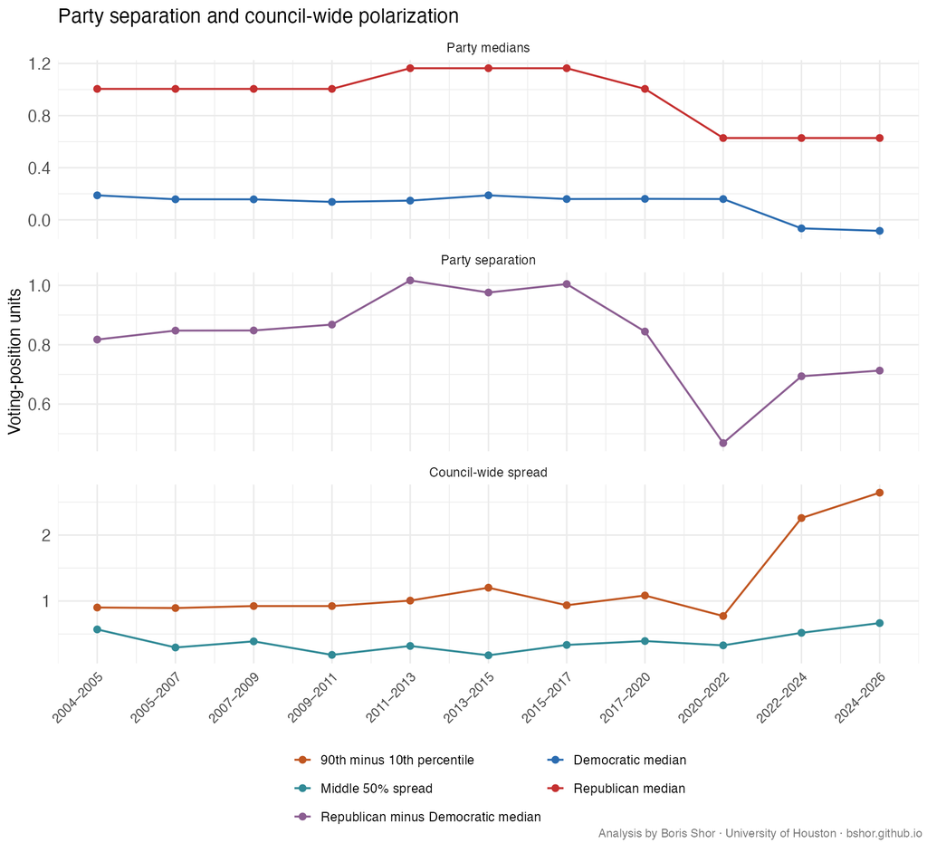

| Council window | Members | Democratic-affiliated | Republican-affiliated |
| --- | --- | --- | --- |
| 2004–2005 | 15 | 13 | 1 |
| 2005–2007 | 16 | 14 | 1 |
| 2007–2009 | 15 | 13 | 1 |
| 2009–2011 | 15 | 13 | 1 |
| 2011–2013 | 16 | 14 | 1 |
| 2013–2015 | 15 | 14 | 1 |
| 2015–2017 | 15 | 14 | 1 |
| 2017–2020 | 18 | 15 | 3 |
| 2020–2022 | 17 | 16 | 1 |
| 2022–2024 | 14 | 13 | 1 |
| 2024–2026 | 14 | 13 | 1 |

The top panel tracks the two party medians; the middle panel is their signed difference, Republican minus Democratic. The bottom panel measures the council’s overall spread, including differences within the Democratic majority: the middle half of members and the distance between the 10th and 90th percentiles. Republican groups are small, so their medians can represent a single member rather than a broad party bloc. Zine’s changing affiliation is excluded from the static party comparison but included in council-wide spread.

These comparisons describe changing membership on the pooled scale, not individual movement. The earlier estimates remain less settled, as noted below.

## Party affiliation and organizational endorsements

### Party affiliation

| Affiliation evidence | Members |
| --- | --- |
| Democratic | 41 |
| Republican | 3 |
| Republican / later unaffiliated | 1 |

The historical affiliation ledger includes nine Democratic affiliation/alignment claims supported by separate research. Evidence ranges from official party records to dated journalism and institutional biographies; exact affiliation boundaries remain unknown where the sources do not give them. Zine is kept separate because he changed from Republican to no-party registration during his service. Greuel’s earlier Republican history ended before this vote window; Park’s Democratic switch also preceded her council votes. Lee’s Republican claim is dated 2019 rather than verified current registration. Party alone does not capture differences among Democratic-affiliated members.

### DSA endorsements

DSA-LA named Raman, Hernandez and Soto-Martínez as endorsed councilmembers in [November 2023](https://dsa-la.org/dsa-la-city-councilmember-support-ceasefire/). California DSA documented Jurado’s endorsement and the four-member group after the [2024 election](https://www.californiadsa.org/news/los-angeles-election-2024). Socialists in Office coordinates these officeholders; it is not treated as a second independent endorsement group or an invented formal council caucus.

| Council | Comparison | Endorsed | Others | Endorsed median | Others median | Median difference |
| --- | --- | --- | --- | --- | --- | --- |
| 2022–2024 | All fitted members | 3 | 11 | -2.45 | 0.22 | -2.67 |
| 2022–2024 | Within Democratic-affiliated members | 3 | 10 | -2.45 | 0.19 | -2.64 |
| 2024–2026 | All fitted members | 4 | 10 | -1.93 | 0.30 | -2.23 |
| 2024–2026 | Within Democratic-affiliated members | 4 | 9 | -1.93 | 0.23 | -2.16 |

In 2022–2024, every endorsed member’s point estimate lies left of every other fitted member. In 2024–2026, every endorsed member’s point estimate lies left of every other fitted member. This describes point estimates, not guaranteed separation of their uncertainty intervals.

### Abundant Housing LA

AHLA’s housing-abundance endorsements are distinct from DSA’s. Its [2022 update](https://abundanthousingla.org/ahla-endorsed-candidates-update/) documents support for Yaroslavsky and Soto-Martínez. Its [2024 annual list](https://www.abundanthousingla.org/2024-endorsements) includes Raman, Harris-Dawson, Hutt and Nazarian. The latter combines election stages, so it should not be read as one simultaneous slate.

| Member | Documented election year | Pooled voting position |
| --- | --- | --- |
| Katy Young-Yaroslavsky | 2022 | -0.15 |
| Hugo Soto-Martinez | 2022 | -2.45 |
| Adrin Nazarian | 2024 | 0.52 |
| Nithya Raman | 2024 | -0.29 |
| Marqueece Harris-Dawson | 2024 | -0.20 |
| Heather Hutt | 2024 | -0.08 |

The six-member list above covers endorsements documented in **2022 and 2024**. The comparison below is narrower: only incoming members in the **covered 2024 races**, four listed and two not listed. It excludes holdovers and District 6. The within-Democrat row compares those four listed Democrats with Jurado alone.

| Comparison | Endorsed | Others | Endorsed median | Others median | Median difference |
| --- | --- | --- | --- | --- | --- |
| All fitted members | 4 | 2 | -0.14 | -0.39 | 0.25 |
| Within Democratic-affiliated members | 4 | 1 | -0.14 | -1.41 | 1.27 |

The 2024 comparison includes incoming members only in covered races. “Others” means Lee and Jurado were not listed in that reviewed annual source; it is not proof they never received an endorsement. Holdovers and District 6 are not treated as unendorsed controls. Among Democratic-affiliated members, the outside group is Jurado alone, making that comparison descriptive rather than a broad test of AHLA’s politics.

## Interpretation and limits

The pooled scale reveals substantial differences within a largely Democratic council and a distinct DSA-endorsed group. Some early-member estimates remain unsettled, and McOsker’s votes are missing. Detailed construction and estimation limits are in the technical appendix.